# Midterm Project TA

### 6.2.13 Total Cost ~ City

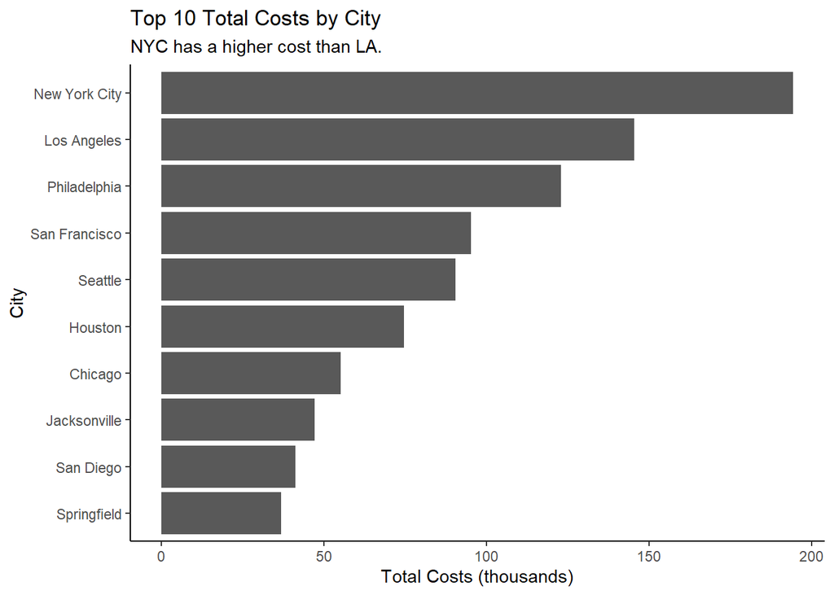

```r
officeMate %>%
  group_by(City) %>%
  summarize(totalCost = sum(Cost)) %>%
  top_n(10, totalCost) %>% #using top 10 to show highest cost cities
  ggplot(mapping = aes(x = reorder(City, totalCost), y = totalCost/1000)) +
  geom_col()+
  coord_flip() +
  theme_classic() +
  labs(title = "Top 10 Total Costs by City", subtitle = "NYC has a higher cost than LA.", x = "City", y = "Total Costs (thousands)")
```

**Comments**

- Confirms that NYC has a high cost, and even higher than LA

### 6.2.14 Region ~ Revenue Total

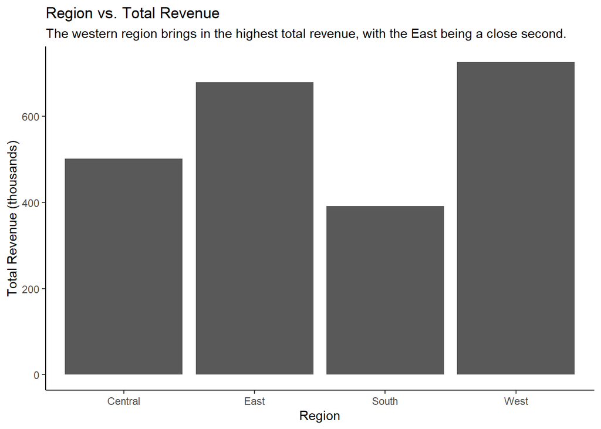

```r
# Region and total revenue
officeMate %>%
  group_by(Region, Revenue) %>%
  summarise(sumRev = sum(Revenue)) %>%
  ggplot(mapping = aes(x = Region, y = sumRev/1000)) + #using revenue, dividing for clarity
  geom_col() +
  theme_classic() +
  labs(title = "Region vs. Total Revenue", subtitle = "The western region brings in the highest total revenue, with the East being a close second.", y = "Total Revenue (thousands)")
```

**Comments**

- East and West have almost the same revenue total
  - Indicates that the West may have the most orders, but East buys more expensive items

### 6.2.15 Region ~ Discount Count

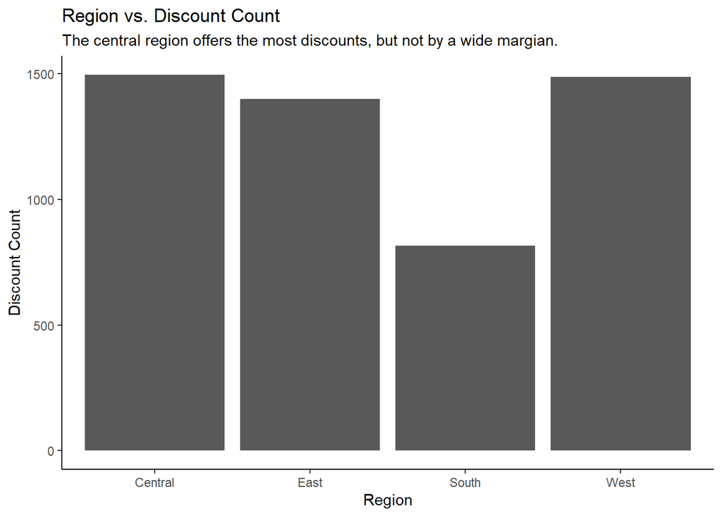

```r
# Bar graph to show count of discounts among the different regions
officeMate %>%
  filter(Discount != 0) %>% #using only discounts
  group_by(Discount, Region) %>%
  summarise(count_dis = n()) %>% #creating a count
  ggplot(mapping = aes(x = Region, y = count_dis)) +
  geom_col() +
  theme_classic() +
  labs(title = "Region vs. Discount Count", subtitle = "The central region offers the most discounts, but not by a wide margian.", y = "Discount Count")
```

**Comments**

### 6.2.16 Region ~ Profit

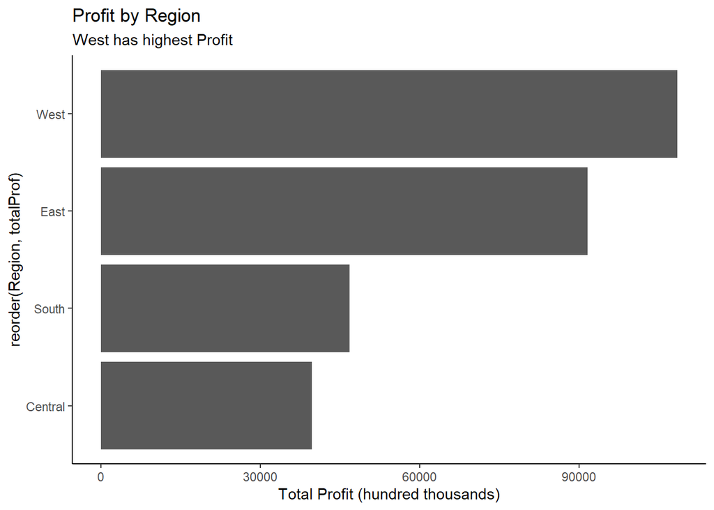

```r
# Bar graph of profit and region
officeMate %>%
  group_by(Region) %>%
  summarize(totalProf = sum(Profit)) %>% #using total profits
  ggplot(mapping = aes(x = reorder(Region, totalProf), y = totalProf)) +
  geom_col()+
  coord_flip() +
  theme_classic() +
  labs(title = "Profit by Region", subtitle = "West has highest Profit", y = "Total Profit (hundred thousands)")
```

**Comments**

- South has a higher profit than Central, despite being lowest in Revenue
- Confirms that the larger discount count affects the revenue

**Questions**

- Does a proportion of discount confirm that Central has more discounts?

### 6.2.17 Average Discount ~ Sub.Category

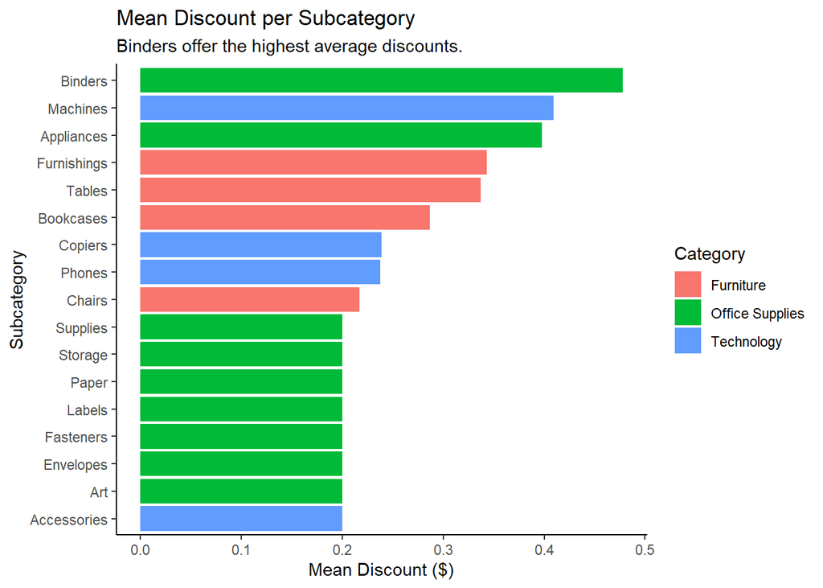

```r
# Mean discount per subcategory colored by category
# Shows distribution of discounts as well as the amounts
officeMate %>%
  filter(Discount != 0) %>% #using only discounts
  group_by(Sub.Category, Category) %>%
  summarize(meanDisc = mean(Discount)) %>%
  ggplot(mapping = aes(x = reorder(Sub.Category, meanDisc), y = meanDisc, fill = Category)) +
  geom_col() +
  coord_flip() +
  theme_classic() +
  labs(title = "Mean Discount per Subcategory", subtitle = "Binders offer the highest average discounts.", x = "Subcategory", y = "Mean Discount ($)")
```

**Comments**

- The subcategories with higher discounts may have lower profits
  - Graph in the detailed EDA

### 6.2.18 Revenue over time

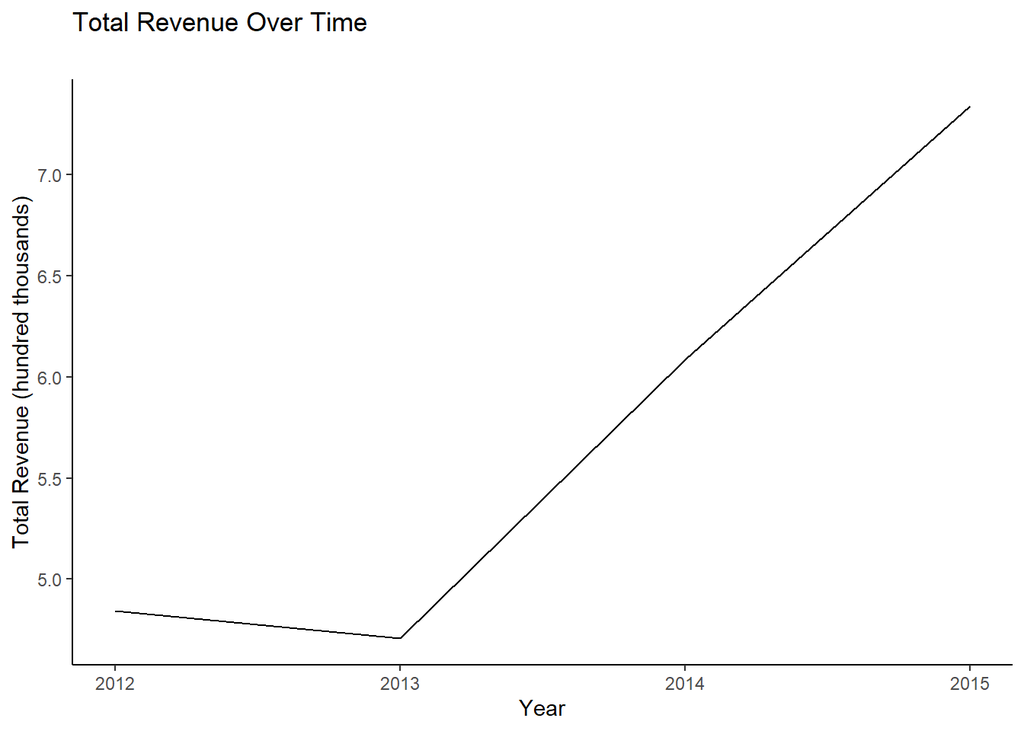

```r
# Revenue over time, revenue in hundred thousands
officeMate %>%
  mutate(yr = year(Order.Date)) %>%
  group_by(yr) %>%
  summarise(sumRev = sum(Revenue)) %>%  #using sum revenue
  ggplot(mapping = aes(x = yr, y = sumRev/100000)) +
  geom_line() +
  theme_classic() +
  labs(title = "Total Revenue Over Time", subtitle = "", x = "Year", y = "Total Revenue (hundred thousands)")
```

**Comments**

- Revenue increases after 2013
- Better visualizes our earlier faceted graphs

# 7 Detailed EDA

## 7.1 Questions

- Does discount affect why Central Region have lower profits than South despite being a larger consumer?
- Do different ship times have different profits?
- Does the breakdown of segments differ between NYC and LA? Does it explain why NYC has higher profits?
- What is the relationship between Discounts and specific products?

### 7.1.1 NYC-LA Profit ~ Segment

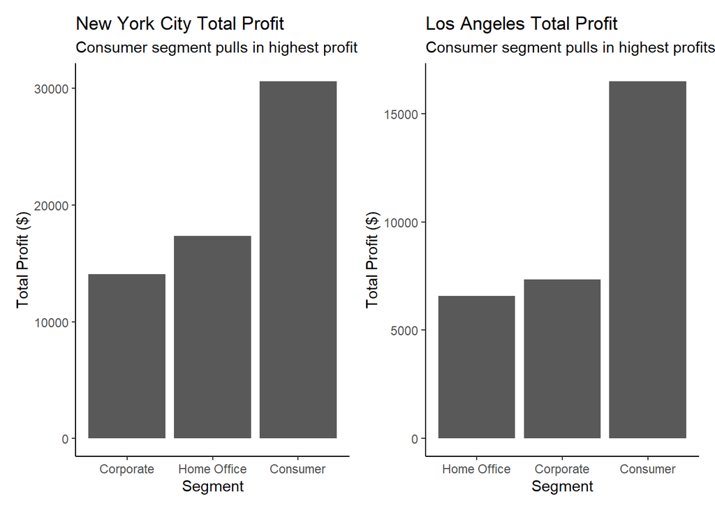

```r
# Bar graph of City Profit (NY and LA)
# Divided by segment
nyProfit <- officeMate %>%
  filter(City == "New York City") %>% #want to see only NYC
  group_by(Segment) %>%
  summarize(totalProf = sum(Profit)) %>% #using total profit
  ggplot(mapping = aes(x = reorder(Segment, totalProf), y = totalProf)) +
  geom_col() +
  theme_classic() +
  labs(title = "New York City Total Profit", subtitle = "Consumer segment pulls in highest profits.", x = "Segment", y = "Total Profit ($)")

caliProfit <- officeMate %>%
  filter(City == "Los Angeles") %>% #want to see only LA
  group_by(Segment) %>%
  summarize(totalProf = sum(Profit)) %>% #using total profit
  ggplot(mapping = aes(x = reorder(Segment, totalProf), y = totalProf)) +
  geom_col() +
  theme_classic() +
  labs(title = "Los Angeles Total Profit", subtitle = "Consumer segment pulls in highest profits.", x = "Segment", y = "Total Profit ($)")

nyProfit + caliProfit
```

**Comments**

- Despite NYC having higher profit, both cities have similar segment distributions
- In NYC, the Home Office segment is larger than the Corporate segmant compared to LA
- Both have very large consumer segments

### 7.1.2 Region ~ Count ~ Discount

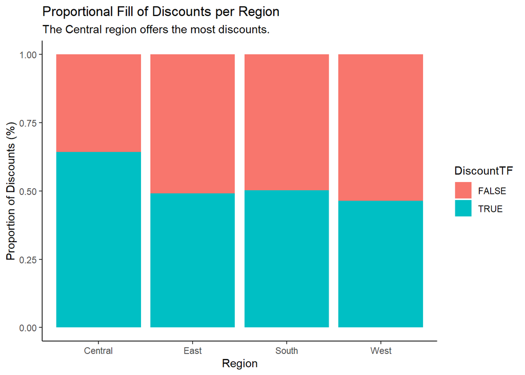

```r
# Proportion of discount to no discount for each region.
officeMate %>%
  mutate(DiscountTF = Discount != 0) %>% #using only discount
  ggplot(mapping = aes(x = Region, fill = DiscountTF)) +
  geom_bar(position = "fill") +
  theme_classic() +
  labs(title = "Proportional Fill of Discounts per Region", subtitle = "The Central region offers the most discounts.", y = "Proportion of Discounts (%)")
```

**Comments**

- Confirms that central region has the most discounts proportionally
- Indicates that more discounts could lead to less profits
- Answers our question on Central region’s relationship with discounts

### 7.1.3 Region ~ Profit ~ Discount

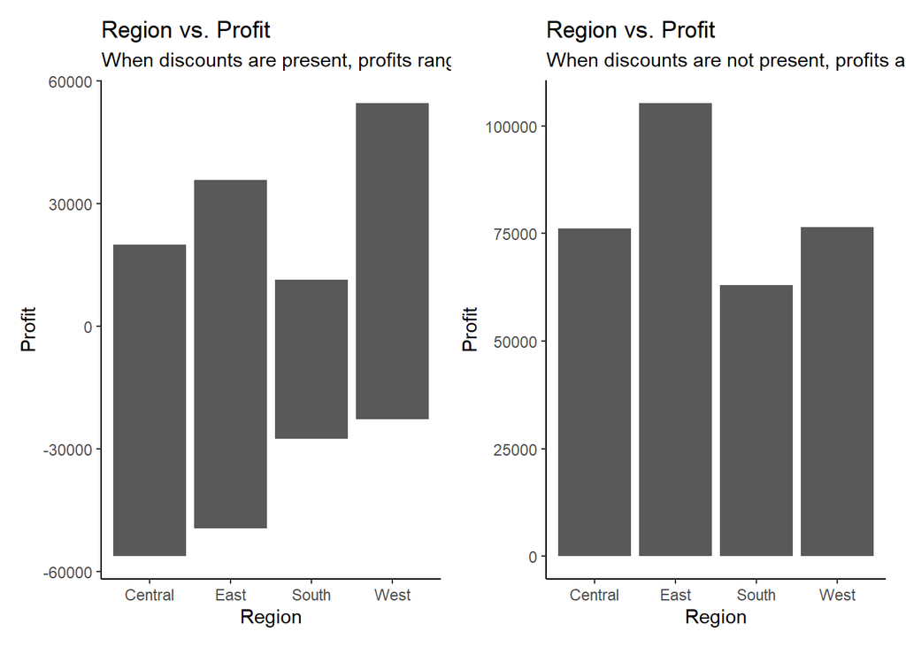

```r
# Discount is present, bar graph for Regions
y1 <- officeMate %>%
  filter(Discount != 0) %>% #using only discount
  ggplot(mapping = aes(x = Region, y = Profit)) +
  geom_col() +
  theme_classic() +
  labs(title = "Region vs. Profit", subtitle = "When discounts are present, profits range widely between positive and negative values.")

# Discount is absent, bar graph for Regions
x1 <- officeMate %>%
  filter(Discount == 0) %>% #using non discount
  ggplot(mapping = aes(x = Region, y = Profit)) +
  geom_col() +
  theme_classic() +
  labs(title = "Region vs. Profit", subtitle = "When discounts are not present, profits are always positive.")

y1 + x1
```

**Comments**

- Displays the range of profits when there is a discount vs no discount
- Confirms that central region has the lowest profits and the most amount of discounts
- Further provides rationale for reducing the number of discounts when the previous graph is taken into account

### 7.1.4 Year ~ Median Profit ~ Ship Time

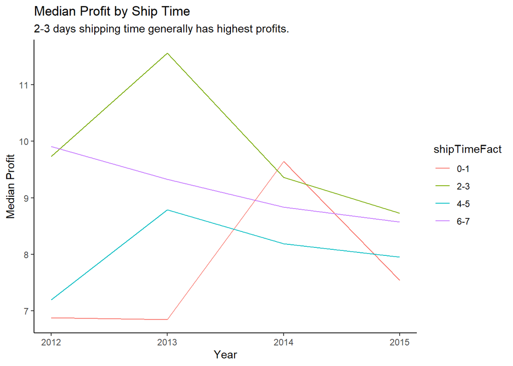

```r
# Profit data is skewed, so we used median instead of mean
officeMate$shipTimeFact <- as.factor(officeMate$shipTime)

officeMate %>%
  mutate(yr = year(Order.Date)) %>%
  mutate(shipTimeFact = fct_recode(shipTimeFact, `0-1` = "0", `0-1` = "1", `2-3` = "2", `2-3` = "3", `4-5` = "4", `4-5` = "5", `6-7` = "6", `6-7` = "7")) %>% #refactoring shiptime for clarity
  group_by(shipTimeFact, yr) %>%
  summarise(med_prof = median(Profit)) %>%  #using median profits
  ggplot(mapping = aes(x = yr, y = med_prof, color = shipTimeFact)) +
  geom_line() +
  theme_classic() +
  labs(title = "Median Profit by Ship Time", subtitle = "2-3 days shipping time generally has highest profits.", x = "Year", y = "Median Profit")
```

**Comments**

- Median profit has decreased overtime despite Revenue increasing
- Shipping times between 2-5 days have a peak in 2013 whereas 0-1 day shipping peaks in 2014
- Because there are multiple ship times per ship mode factor, this could explain the similarities in trends

### 7.1.5 Discount ~ Total Profit ~ Category

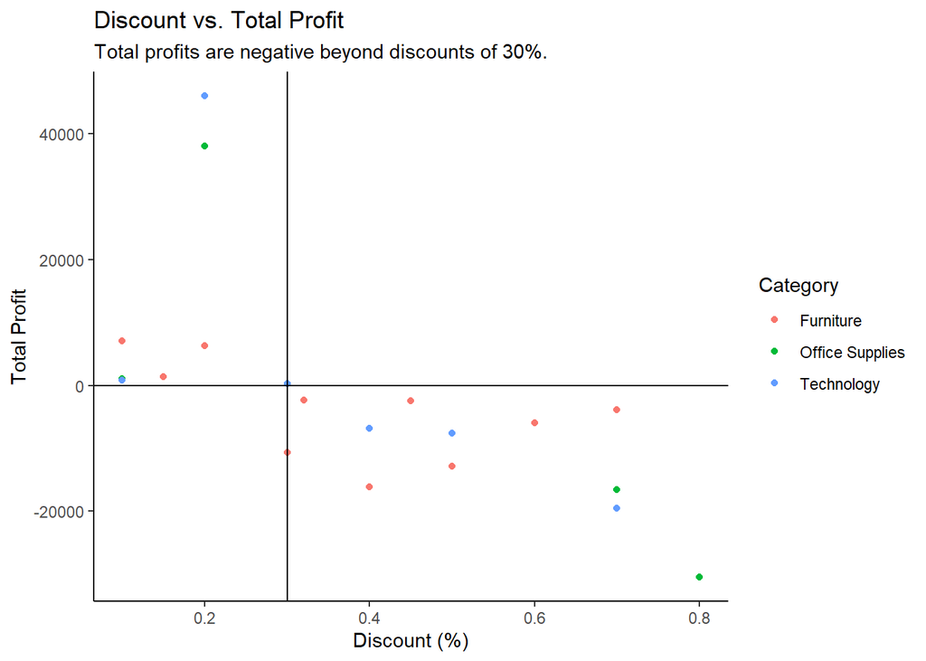

```r
# Scatterplot to see where profit becomes negative (at what discount level)
officeMate %>%
  filter(Discount > 0) %>%
  group_by(Discount, Category) %>%
  summarise(sumProf = sum(Profit)) %>%
  ggplot(mapping = aes(x = Discount, y = sumProf, color = Category)) +
  geom_point() +
  geom_vline(xintercept = 0.3) + #adding a vertical line at .3, divides positive and negative
  geom_hline(yintercept = 0) + #adding a horizontal breakeven point
  theme_classic() +
  labs(title = "Discount vs. Total Profit", subtitle = "Total profits are negative beyond discounts of 30%.", x = "Discount (%)", y = "Total Profit")
```

**Comments**

- Scatter plot of discount and cateory shows that some office supplies have the lowest profits and highest discounts
- Discounts of less than 30% have positive profits
  - Relationship may need to be further analysed

### 7.1.6 Discount ~ Profit ~ Subcategory

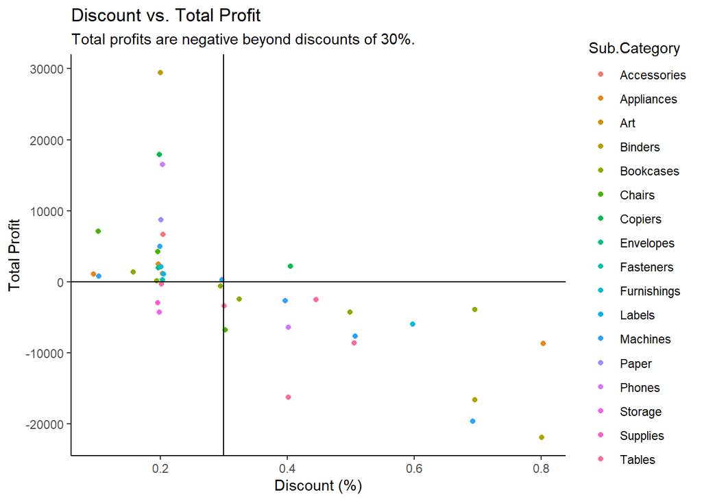

```r
# Scatterplot of discount levels and profit
officeMate %>%
  filter(Discount > 0) %>%
  group_by(Discount, Sub.Category) %>%
  summarise(sumProf = sum(Profit)) %>%
  ggplot(mapping = aes(x = Discount, y = sumProf, color = Sub.Category)) +
  geom_point(position = "jitter") +
  geom_vline(xintercept = 0.3) + #adding a vertical line at .3, divides positive and negative profits
  geom_hline(yintercept = 0) + #adding a horizontal breakeven point
  theme_classic() +
  labs(title = "Discount vs. Total Profit", subtitle = "Total profits are negative beyond discounts of 30%.", x = "Discount (%)", y = "Total Profit")
```

**Comments**

- See correlation test in statistical EDA
- Same as the above graph but for sub category
- Graph is too messy, overplotted
  - A filter may be needed to pinpoint our exact finding
  - Focus on the lowest profits?

### 7.1.7 Revenue ~ Subcategory || Discount Count ~ Subcategory

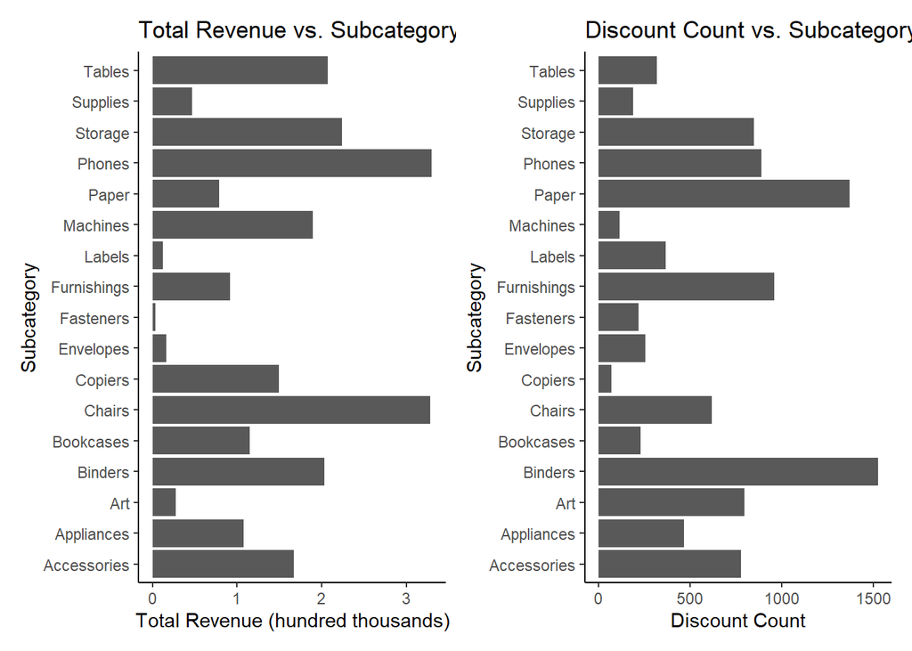

```r
# Creating graph of total revenue by sub category
svg <- officeMate %>%
  group_by(Revenue, Sub.Category) %>%
  summarize(totalRev = sum(Revenue)) %>%
  ggplot(mapping = aes(x = Sub.Category, y = totalRev/100000)) + #using sums of revenue
  geom_col() +
  theme_classic() +
  labs(title = "Total Revenue vs. Subcategory", x = "Subcategory", y = "Total Revenue (hundred thousands)") +
  coord_flip()

# Creating graph of discount count by sub category
efj <- officeMate %>%
  group_by(Discount, Sub.Category) %>%
  summarize(countDis = n()) %>%
  ggplot(mapping = aes(x = Sub.Category, y = countDis)) +
  geom_col() +
  theme_classic() +
  labs(title = "Discount Count vs. Subcategory", x = "Subcategory", y = "Discount Count") +
  coord_flip()

svg + efj
```

**Comments**

- Side by side comparison
  - Helps us see high revenue items that may have more discounts
  - Maybe keep high rev items if there are large enough profits?

### 7.1.8 Revenue ~ Subcategory ~ Discount

```r
# Do discounts at higher rates bring in more customers and as a result more revenue?
Discount_Factor <- as.factor(officeMate$Discount)

officialMemoViz1 <- officeMate %>%
  mutate(Discount_Factor = fct_recode(Discount_Factor, `0 - 30%` = "0", `0 - 30%` = "0.1", `0 - 30%` = "0.15", `0 - 30%` = "0.2", `0 - 30%`= "0.3", `30 - 50%`= "0.32", `30 - 50%`= "0.4", `30 - 50%` = "0.45", `30 - 50%` = "0.5", `51 - 80%` = "0.6", `51 - 80%` = "0.7", `51 - 80%` = "0.8")) %>% #refactoring discount levels
  group_by(Revenue, Sub.Category, Discount_Factor, Discount) %>%
  filter(Discount_Factor != "0 - 30%") %>% #filtering out 20% discounts
  summarise(meanRev = mean(Revenue)) %>%
  ggplot(mapping = aes(x = reorder(Sub.Category, Discount), y = meanRev/10000, fill = Discount_Factor)) +
  geom_bar(stat = "identity") +
  theme_classic() +
  labs(title = "Mean Revenue vs. Subcategory", subtitle = "Higher discounts do not necessarily mean more revenue.", x = "Subcategory", y = "Mean Revenue (ten thousands)")
  coord_flip()
```

[output not shown]

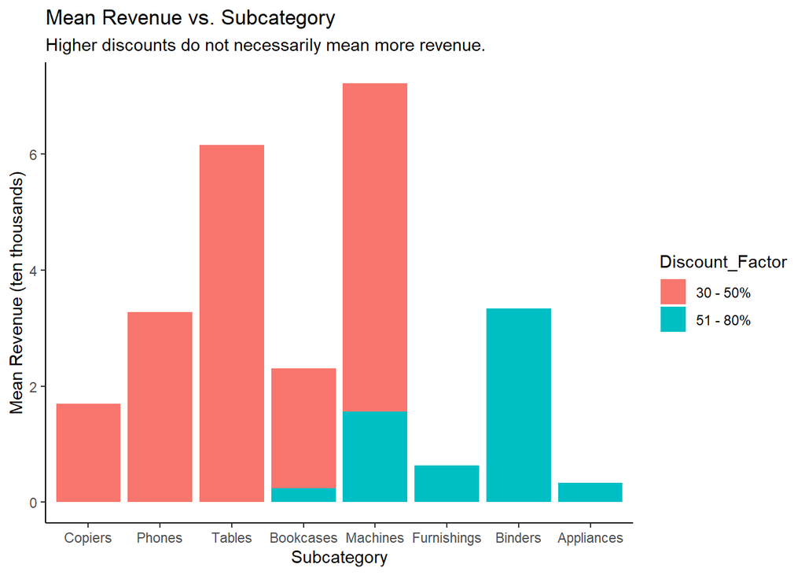

```r
officialMemoViz1
```

**Comments**

- Filtered out discounts 20% and lower
- When compared with the previous graph, we see that appliances and furnishings are low reveneue items with high discounts
  - We know that 50-80% items have negative profits
- Phones and tables are high revenue items with lower percentage of discounts

### 7.1.9 Profit ~ Subcategory

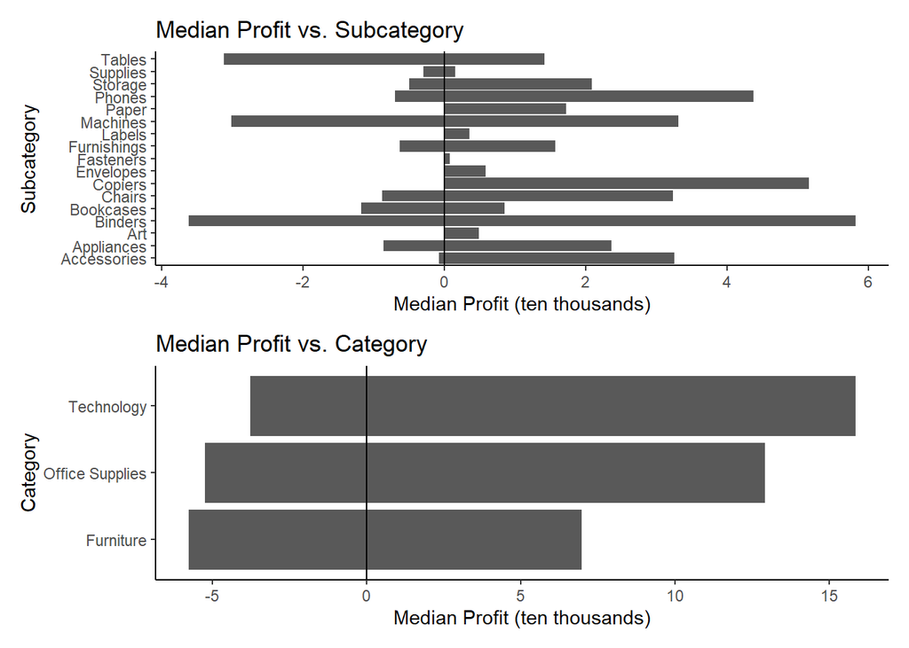

```r
# Median profit range for subcategories and categories
g1 <- officeMate %>%
  group_by(Sub.Category, Profit, Category) %>%
  summarize(medProf = median(Profit)) %>%
  ggplot(mapping = aes(x = Sub.Category, y = medProf/10000)) +  #using median profits
  geom_bar(stat = "identity") +
  coord_flip() +
  geom_hline(yintercept = 0) +
  theme_classic() +
  labs(title = "Median Profit vs. Subcategory", x = "Subcategory", y = "Median Profit (ten thousands)")

g2 <- officeMate %>%
  group_by(Profit, Category) %>%
  summarize(medProf = median(Profit)) %>%
  ggplot(mapping = aes(x = Category, y = medProf/10000)) +   #using median profits
  geom_bar(stat = "identity") +
  coord_flip() +
  geom_hline(yintercept = 0) +
  theme_classic() +
  labs(title = "Median Profit vs. Category", x = "Category", y = "Median Profit (ten thousands)")

g1 / g2
```

**Comments**

- Another visual on breakdown of profit range
- Binders and machines have very large ranges of profits
  - Profitability may improve with reducing discounts
  - Reducing discounts may then reduce their revenue count
  - Wins/losses should be examined
- Furniture has the lowest profits amongst all categories

### 7.1.10 Discount ~ Profit ~ True/False

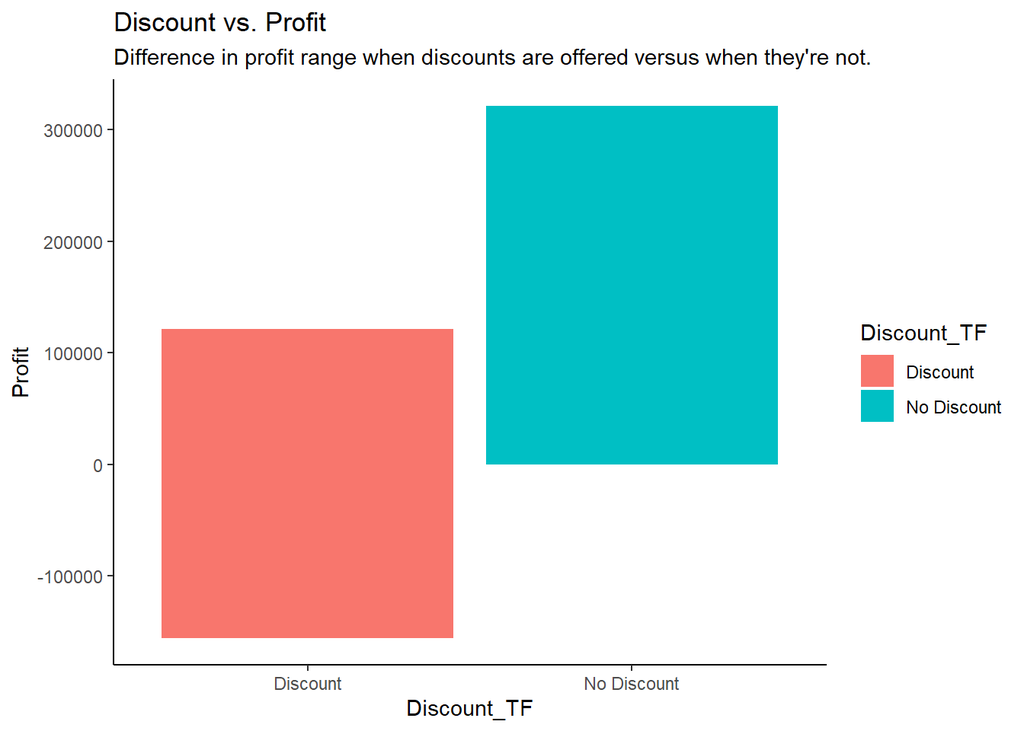

```r
# Find distribution of profits when discount is given and when there is no discount
memo1 <- officeMate %>%
  select(Discount, Profit) %>%
  mutate(Discount_TF = as.factor(ifelse(Discount > 0, "Discount", "No Discount"))) %>%
  group_by(Discount, Profit) %>%
  ggplot(mapping = aes(x = Discount_TF, y = Profit, fill = Discount_TF)) + #using median price
  geom_col() +
  theme_classic() +
  labs(title = "Discount vs. Profit", subtitle = "Difference in profit range when discounts are offered versus when they're not.")

memo1
```

**Comments**

- Profits without discounts are always positive, with a much higher maximum of 300,000
- Profits where a discount is offered has a range from about -150,000 to 100,000
  - Perhaps offering less discounts would have higher profit
  - Would need to check the statistical significance of this
  - A breakdown of which discounts lead to lower profits may be beneficial

### 7.1.11 Discount ~ Profit

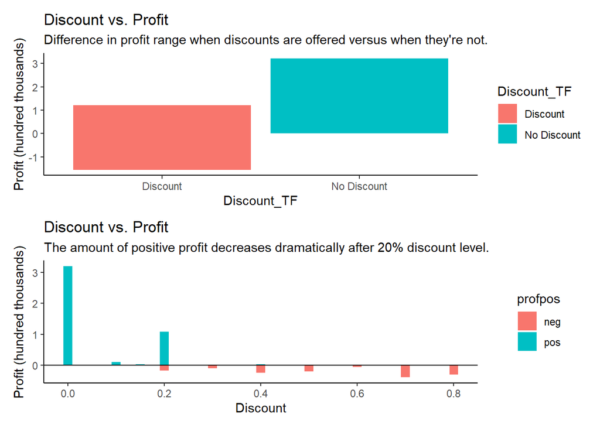

```r
# Create second image for memo
DiscProf2 <- officeMate %>%
  mutate(profpos = ifelse(Profit >= 0, "pos", "neg")) %>% #refactoring profit
  group_by(Discount) %>%
  ggplot(mapping = aes(x = Discount, y = Profit/100000, fill = profpos)) + #using median price
  geom_bar(stat = "identity") +
  geom_hline(yintercept = 0) +
  theme_classic() +
  labs(title = "Discount vs. Profit", subtitle = "The amount of positive profit decreases dramatically after 20% discount level.", y = "Profit (hundred thousands)")

DiscProf1 <- officeMate %>%
  select(Discount, Profit) %>%
  mutate(Discount_TF = as.factor(ifelse(Discount > 0, "Discount", "No Discount"))) %>% #refactoring profit
  group_by(Discount, Profit) %>%
  ggplot(mapping = aes(x = Discount_TF, y = Profit/100000, fill = Discount_TF)) + #using median price
  geom_col() +
  theme_classic() +
  labs(title = "Discount vs. Profit", subtitle = "Difference in profit range when discounts are offered versus when they're not.", y = "Profit (hundred thousands)")

officialMemoViz2 <- DiscProf1 / DiscProf2
officialMemoViz2
```

**Comments**

# 8 Statistical Analysis

### 8.0.1 Profit ~ Discount

```r
# Pairwise T Test to see relation between factor levels of discount and Revenue.
pairwise.t.test(officeMate$Profit, as.factor(officeMate$Discount))
```

```
##
##  Pairwise comparisons using t tests with pooled SD
##
## data:  officeMate$Profit and as.factor(officeMate$Discount)
##
##      0                    0.1                  0.15
## 0.1  1.00000              -                    -
## 0.15 1.00000              1.00000              -
## 0.2  0.0000000000000017   0.07897              1.00000
## 0.3  0.0000000000154922   0.0000164398503103   0.73216
## 0.32 0.01326              0.00730              0.66145
## 0.4  < 0.0000000000000002 0.0000000000101585   0.00306
## 0.45 0.00076              0.00035              0.02414
## 0.5  < 0.0000000000000002 < 0.0000000000000002 0.0000000000000605
## 0.6  0.0000009551420445   0.00020              1.00000
## 0.7  < 0.0000000000000002 0.0000000000074970   0.00815
## 0.8  < 0.0000000000000002 0.0000000000094165   0.00588
##      0.2                  0.3                0.32    0.4                0.45
## 0.1  -                    -                  -       -                  -
## 0.15 -                    -                  -       -                  -
## 0.2  -                    -                  -       -                  -
## 0.3  0.00025              -                  -       -                  -
## 0.32 0.25531              1.00000            -       -                  -
## 0.4  0.0000000000000028   0.07546            1.00000 -                  -
## 0.45 0.00866              0.25531            1.00000 1.00000            -
## 0.5  < 0.0000000000000002 0.0000000000000044 0.00076 0.0000000294442032 1.00000
## 0.6  0.01909              1.00000            1.00000 0.16380            0.25531
## 0.7  < 0.0000000000000002 0.19829            1.00000 1.00000            1.00000
## 0.8  < 0.0000000000000002 0.14412            1.00000 1.00000            1.00000
##      0.5                0.6     0.7
## 0.1  -                  -       -
## 0.15 -                  -       -
## 0.2  -                  -       -
## 0.3  -                  -       -
## 0.32 -                  -       -
## 0.4  -                  -       -
## 0.45 -                  -       -
## 0.5  -                  -       -
## 0.6  0.0000000000002014 -       -
## 0.7  0.0000000000476713 0.39329 -
## 0.8  0.0000000006642234 0.27461 1.00000
##
## P value adjustment method: holm
```

**Comments**

- This pairwise t-test shows the probability that profit differs per discount percentage
- We can see that at a high confidence intervals, discounts at or below 20% are statistically different that discounts at higher percentages (70-80%).

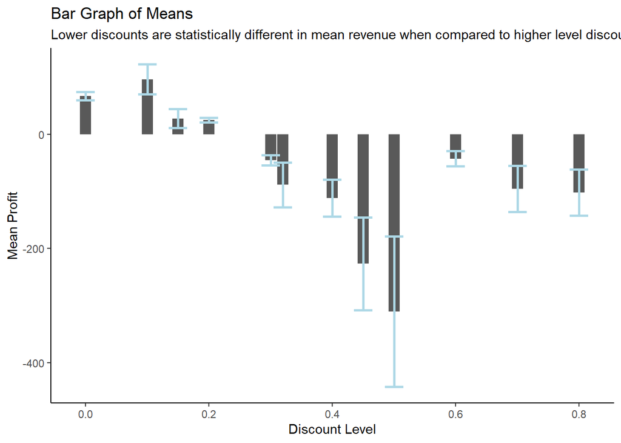

```r
# 95% CI, get z-value for upper tail, use 0.975 since is one sided
z <- qnorm(0.975)

# Incorporate CI into bar graph of means
officeMate %>%
  group_by(Discount) %>%
  summarise(meanProf = mean(Profit), sd = sd(Profit),
            n = n(), ci = z * sd/sqrt(n)) %>%
  ggplot(aes(x = Discount, y = meanProf)) +
  geom_bar(stat = "identity") +
  geom_errorbar(aes(ymin = meanProf - ci, ymax = meanProf + ci),
                width = 0.03, size = 1, color = "light blue") + #adding aesthetics to the confidence intervals
  theme_classic() +
  labs(title = "Bar Graph of Means", subtitle = "Lower discounts are statistically different in mean revenue when compared to higher level discounts.", x = "Discount Level", y = "Mean Profit")
```

**Results**

### 8.0.2 Revenue ~ Discount

```r
# Pairwise T Test to see relation between factor levels of discount on Revenue
pairwise.t.test(officeMate$Revenue, as.factor(officeMate$Discount))
```

```
##
##  Pairwise comparisons using t tests with pooled SD
##
## data:  officeMate$Revenue and as.factor(officeMate$Discount)
##
##      0                    0.1               0.15
## 0.1  0.000001978144290    -                 -
## 0.15 0.01387              1.00000           -
## 0.2  1.00000              0.000000454327733 0.00677
## 0.3  0.000002322097596    1.00000           1.00000
## 0.32 0.24332              1.00000           1.00000
## 0.4  0.000000000000671    1.00000           1.00000
## 0.45 1.00000              1.00000           1.00000
## 0.5  < 0.0000000000000002 0.04545           0.04545
## 0.6  0.02476              0.000000006222999 0.000065911527886
## 0.7  0.00149              0.000000000402696 0.000074444388990
## 0.8  0.00014              0.000000000041613 0.000013993616131
##      0.2                  0.3               0.32    0.4
## 0.1  -                    -                 -       -
## 0.15 -                    -                 -       -
## 0.2  -                    -                 -       -
## 0.3  0.000000270000912    -                 -       -
## 0.32 0.16287              1.00000           -       -
## 0.4  0.000000000000041    1.00000           1.00000 -
## 0.45 1.00000              1.00000           1.00000 1.00000
## 0.5  < 0.0000000000000002 0.000016242557757 0.29438 0.00619
## 0.6  0.07415              0.000000048193216 0.00611 0.000000000001339
## 0.7  0.01410              0.000000000102058 0.01121 < 0.0000000000000002
## 0.8  0.00149              0.000000000011137 0.00400 < 0.0000000000000002
##      0.45    0.5                  0.6     0.7
## 0.1  -       -                    -       -
## 0.15 -       -                    -       -
## 0.2  -       -                    -       -
## 0.3  -       -                    -       -
## 0.32 -       -                    -       -
## 0.4  -       -                    -       -
## 0.45 -       -                    -       -
## 0.5  1.00000 -                    -       -
## 0.6  0.48076 < 0.0000000000000002 -       -
## 0.7  0.75047 < 0.0000000000000002 1.00000 -
## 0.8  0.48076 < 0.0000000000000002 1.00000 1.00000
##
## P value adjustment method: holm
```

**Comments**

- The pairwise t-test shows the probability that the revenue is statistically different at each discount level.
- We can see that there is some variation across all discount levels, however, the zero discount level has the most probable differences when compared to other levels

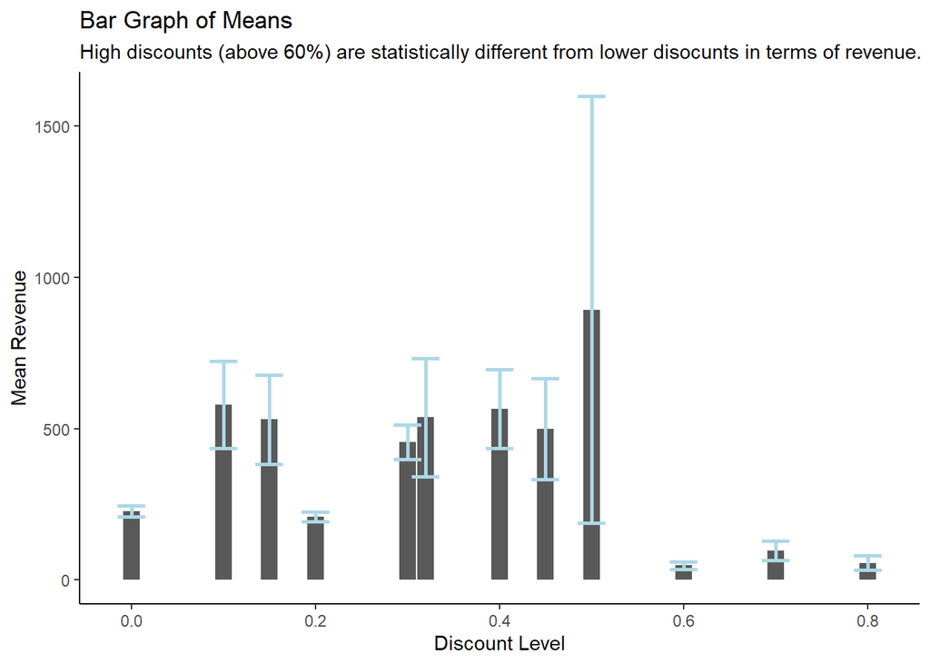

```r
# 95% CI, get z-value for upper tail, use 0.975 since is one sided
z <- qnorm(0.975)

# Incorporate CI into bar graph of means
officeMate %>%
  group_by(Discount) %>%
  summarise(meanRev = mean(Revenue), sd = sd(Revenue),
            n = n(), ci = z * sd/sqrt(n)) %>%
  ggplot(aes(x = Discount, y = meanRev)) +
  geom_bar(stat = "identity") +
  geom_errorbar(aes(ymin = meanRev - ci, ymax = meanRev + ci),
                width = 0.03, size = 1, color = "light blue") + #adding aesthetics to the confidence intervals
  theme_classic() +
  labs(title = "Bar Graph of Means", subtitle = "High discounts (above 60%) are statistically different from lower disocunts in terms of revenue.", x = "Discount Level", y = "Mean Revenue")
```

**Results**

### 8.0.3 Profit ~ Discount Relationship || Pearson Correlation Test

```r
cor.test(officeMate$Profit, officeMate$Discount, method = c("pearson"))
```

```
##
##  Pearson's product-moment correlation
##
## data:  officeMate$Profit and officeMate$Discount
## t = -22.488, df = 9992, p-value < 0.00000000000000022
## alternative hypothesis: true correlation is not equal to 0
## 95 percent confidence interval:
##  -0.2380692 -0.2007456
## sample estimates:
##        cor
## -0.2194877
```

**Comments**

- Only wanting to show the negative relationship between discount and profit
- Our correlation value of -0.219 shows there is a negative relationship
- Important to note that the profit variable has multiple drivers other than discount, for this reason, regression would not be appropriate here
- A regression would cause omitted variable bias (Y = β + β1A versus Y = β + β1A + β2A)
- See scatterplots in Detailed EDA for a visual breakdown of the relationship

# 9 Summary

- In general, discounts lead to less profits
  - This is relative to the percentage of discounts, higher discounts lead to negative profits
- Certain products have high revenues that justify their discounts while others do not
  - Some furniture products have low revenues and low profits but high discounts
  - These types of products may need to be reevaulated
- Consumer segment dominate the revenues of cities
  - NYC is more profitable than LA but segment does not play a large role in this
- Higher count of discounts in the Central region may have contributed to the low profits compared to the South
  - Important because the South generates less revenue but is more profitable
- Our two findings on discounts and profit, and discounts and product revenue were found to be statistically significant

# 10 Professional Visuals

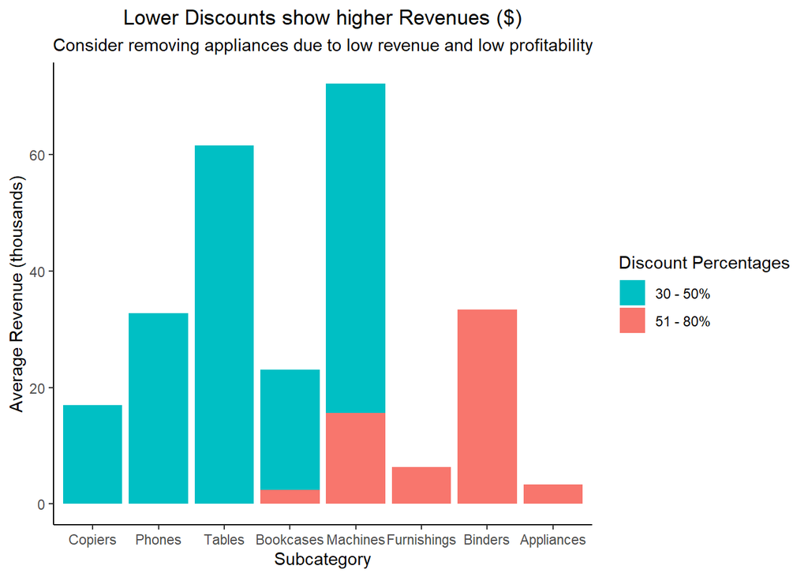

```r
# Do discounts at higher rates bring in more customers and as a result more revenue?
Discount_Factor <- as.factor(officeMate$Discount)

officialMemoViz1 <- officeMate %>%
  mutate(Discount_Factor = fct_recode(Discount_Factor, `0 - 30%` = "0", `0 - 30%` = "0.1", `0 - 30%` = "0.15", `0 - 30%` = "0.2", `0 - 30%`= "0.3", `30 - 50%`= "0.32", `30 - 50%`= "0.4", `30 - 50%` = "0.45", `30 - 50%` = "0.5", `51 - 80%` = "0.6", `51 - 80%` = "0.7", `51 - 80%` = "0.8")) %>% #refactoring discount levels for clarity
  group_by(Revenue, Sub.Category, Discount_Factor, Discount) %>%
  filter(Discount_Factor != "0 - 30%") %>% #filtering out 20% and lower
  summarise(meanRev = mean(Revenue)) %>%
  ggplot(mapping = aes(x = reorder(Sub.Category, Discount), y = meanRev/1000, fill = Discount_Factor)) +
  geom_bar(stat = "identity") +
  theme_classic() +
  labs(title = "Lower Discounts show higher Revenues ($)", subtitle = "Consider removing appliances due to low revenue and low profitability", x = "Subcategory", y = "Average Revenue (thousands)", fill = "Discount Percentages") +
  theme(plot.title = element_text(hjust = 0.5), plot.subtitle =element_text(hjust = 0.5)) +
  scale_fill_manual(values = c("#00BFC4", "#F8766D"))

officialMemoViz1
```

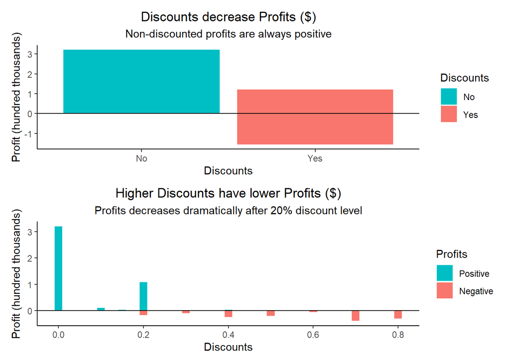

```r
# Create second image for memo
DiscProf2 <- officeMate %>%
  mutate(Profits = ifelse(Profit >= 0, "Positive", "Negative")) %>% #creating legend, and refactoring profit
  group_by(Discount) %>%
  ggplot(mapping = aes(x = Discount, y = Profit/100000, fill = Profits)) + #using median price
  geom_bar(stat = "identity") +
  geom_hline(yintercept = 0) +
  theme_classic() +
  labs(title = "Higher Discounts have lower Profits ($)", subtitle = "Profits decreases dramatically after 20% discount level", y = "Profit (hundred thousands)", x = "Discounts") +
  theme(plot.title = element_text(hjust = 0.5), plot.subtitle =element_text(hjust = 0.5)) +
  guides(fill = guide_legend(reverse = TRUE))

DiscProf1 <- officeMate %>%
  select(Discount, Profit) %>%
  mutate(Discounts = as.factor(ifelse(Discount > 0, "Yes", "No"))) %>% #creating legend, and refactoring discount
  group_by(Discount, Profit) %>%
  ggplot(mapping = aes(x = Discounts, y = Profit/100000, fill = Discounts)) + #using median price
  geom_col() +
  geom_hline(yintercept = 0) + #adding a horizontal line to highlight breakeven point
  theme_classic() +
  labs(title = "Discounts decrease Profits ($)", subtitle = "Non-discounted profits are always positive", y = "Profit (hundred thousands)") +
  theme(plot.title = element_text(hjust = 0.5), plot.subtitle =element_text(hjust = 0.5)) +
  scale_fill_manual(values = c("#00BFC4", "#F8766D"))

officialMemoViz2 <- DiscProf1 / DiscProf2
officialMemoViz2
```

```r
# Save both images to jpg files.
ggsave(filename = "plot1.jpg", plot = officialMemoViz1)
ggsave(filename = "plot2.jpg", plot = officialMemoViz2)
```